# Effective Dimension Algorithm in

# `qiskit-machine-learning`

*Qiskit Demo Day (May 12, 2022)*

#### Elena Peña Tapia

## Index:

1. Intro: Effective Dimension and Local Effective Dimension
2. Algorithm Overview
3. Qiskit Implementation
4. Future Steps

## 1. Intro: Effective Dimension and Local Effective Dimension

2 source papers:

1. *The Power of Quantum Neural Networks*, by Abbas et al. (2020)
2. *Effective Dimension of Machine Learning Models*, by Abbas et al. (2021)

[figure not shown]

### Effective Dimension:

- **Metric** based on **information geometry**: "How many *active* parameters does the model have?"
- Related to **Expressibility** and **Generalization ability**
- Valid for classical and quantum NNs

[figure not shown]

### Local Effective Dimension:

- Measure of capacity based on **Effective Dimension**
- Key difference: 1 parameter set sample vs. full parameter space (weights)
- **Generalization ability** for **Trained Models**: performance of trained models on tasks involving new data

## 2. Algorithm Overview

- **Step 1: Define an input/weight/data sample space**
- **Step 2: Run Algorithm** --> *Fisher Information Matrix*

## 2. Algorithm Overview

1. **Monte Carlo simulation:** for pairs of input and weight samples.
2. **Fisher Info. Matrix Computation**
3. **Fisher Info. Matrix Normalization:** averaging over all input samples and dividing by the matrix trace
4. **Effective Dimension Calculation:** according to the formula from [*Abbas et al.*](https://arxiv.org/pdf/2011.00027.pdf):

[figure not shown]

## 3. Qiskit Implementation

2 classes:

1. `EffectiveDimension(qnn, input_samples, weights_samples)`
2. `LocalEffectiveDimension(qnn, input_samples, weights_sample)`

1 method:

`get_effective_dimension(dataset_size=n)`

```python
from qiskit_machine_learning.neural_networks import EffectiveDimension, LocalEffectiveDimension
```

### Example using `EffectiveDimension`

### 1. Define QNN Model

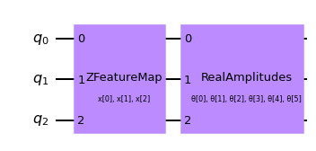

```python
num_qubits = 3
# create a feature map
feature_map = ZFeatureMap(feature_dimension=num_qubits, reps=1)
# create a variational circuit
ansatz = RealAmplitudes(num_qubits, reps=1)

# combine feature map and ansatz into a single circuit
qc = QuantumCircuit(num_qubits)
qc.append(feature_map, range(num_qubits))
qc.append(ansatz, range(num_qubits))
qc.decompose().draw("mpl")
```

```python
# parity maps bitstrings to 0 or 1
def parity(x):
    return "{:b}".format(x).count("1") % 2

output_shape = 2  # corresponds to the number of classes, possible outcomes of the (parity) mapping.
# declare quantum instance
qi_sv = QuantumInstance(Aer.get_backend("aer_simulator_statevector"))

# construct QNN
qnn = CircuitQNN(
    qc,
    input_params=feature_map.parameters,
    weight_params=ansatz.parameters,
    interpret=parity,
    output_shape=output_shape,
    sparse=False,
    quantum_instance=qi_sv,
)
```

The maximum effective dimension of this model will be determined by the number of weights (parameters), in this case:

```python
d = qnn.num_weights
print(f"The maximum effective dimension is {d}")
```

```
The maximum effective dimension is 6
```

### 2. Define input/parameter (weight) space

```python
# we can set the total number of input samples and weight samples for random selection
num_input_samples = 10
num_weight_samples = 10

global_ed = EffectiveDimension(
    qnn=qnn, weight_samples=num_weight_samples, input_samples=num_input_samples
)
```

```python
# we can also provide user-defined samples and parameters
input_samples = algorithm_globals.random.normal(0, 1, size=(10, qnn.num_inputs))
weight_samples = algorithm_globals.random.uniform(0, 1, size=(10, qnn.num_weights))

global_ed = EffectiveDimension(qnn=qnn, weight_samples=weight_samples, input_samples=input_samples)
```

### 3. Define dataset size

```python
# we will define ranges to test different dataset sizes
n = [5000, 8000, 10000, 40000, 60000, 100000, 150000, 200000, 500000, 1000000]
```

### 4. Compute Effective Dimension

Let's see the effective dimension of our model for a predicted dataset size of 5000 samples:

```python
global_eff_dim_0 = global_ed.get_effective_dimension(dataset_size=n[0])

print(f"The effective dimension for {n[0]} samples is {global_eff_dim_0}.")
print(f"The maximum effective dimension for this model is {qnn.num_weights}.\n")
print(f"The normalized effective dimension for {n[0]} samples is {global_eff_dim_0/qnn.num_weights}.")
```

```
The effective dimension for 5000 samples is 4.665650959920609.
The maximum effective dimension for this model is 6.

The normalized effective dimension for 5000 samples is 0.7776084933201015.
```

By calling the `EffectiveDimension` class with an array of sample sizes `n`, we can monitor how the effective dimension changes with the dataset size.

```python
global_eff_dim_1 = global_ed.get_effective_dimension(dataset_size=n)
```

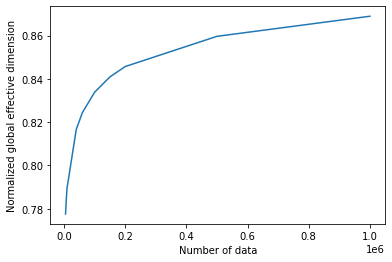

```python
# plot the normalized effective dimension for the model
plt.plot(n, np.array(global_eff_dim_1) / d)
plt.xlabel("Number of data")
plt.ylabel("Normalized global effective dimension")
plt.show()
```

### Example using `LocalEffectiveDimension`

#### 1. Define Dataset and QNN

```python
num_inputs = 3
num_samples = 50
X = algorithm_globals.random.normal(0, 0.5, size=(num_samples, num_inputs))

y01 = 1 * (np.sum(X, axis=1) >= 0)  # in { 0,  1}
y = 2 * y01 - 1  # in {-1, +1}
```

```python
opflow_qnn = TwoLayerQNN(num_inputs, quantum_instance=qi_sv)
```

#### 2. Train QNN

```python
# callback function that draws a live plot when the .fit() method is called
def callback_graph(weights, obj_func_eval):
    clear_output(wait=True)
    objective_func_vals.append(obj_func_eval)
    plt.title("Objective function value against iteration")
    plt.xlabel("Iteration")
    plt.ylabel("Objective function value")
    plt.plot(range(len(objective_func_vals)), objective_func_vals)
    plt.show()
```

```python
# construct classifier
initial_point = algorithm_globals.random.random(opflow_qnn.num_weights)

opflow_classifier = NeuralNetworkClassifier(
    neural_network=opflow_qnn,
    optimizer=COBYLA(maxiter=150),
    initial_point=initial_point,
    callback=callback_graph,
)
```

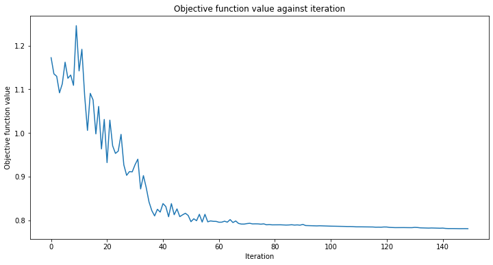

```python
# create empty array for callback to store evaluations of the objective function (callback)
objective_func_vals = []
plt.rcParams["figure.figsize"] = (12, 6)

# fit classifier to data
opflow_classifier.fit(X, y)

# return to default figsize
plt.rcParams["figure.figsize"] = (6, 4)
```

The classifier can now differentiate between classes with an accuracy of:

```python
# score classifier
opflow_classifier.score(X, y)
```

```
0.68
```

#### 3. Compute Local Effective Dimension of trained QNN

```python
# get trained weights from QNN
trained_weights = opflow_classifier._fit_result.x
```

```python
# get Local Effective Dimension for set of trained weights
local_ed_trained = LocalEffectiveDimension(
    qnn=opflow_qnn, weight_samples=trained_weights, input_samples=X
)

local_eff_dim_trained = local_ed_trained.get_effective_dimension(dataset_size=n)

print(
    "normalized local effective dimensions for trained QNN: ",
    local_eff_dim_trained / opflow_qnn.num_weights,
)
```

```
normalized local effective dimensions for trained QNN:  [0.79663244 0.80325759 0.80653351 0.82723511 0.83320702 0.84062917
 0.84641928 0.85045673 0.86276589 0.87134912]
```

#### 4. Compute Local Effective Dimension of untrained QNN

```python
# get Local Effective Dimension for set of untrained weights
local_ed_untrained = LocalEffectiveDimension(
    qnn=opflow_qnn, weight_samples=initial_point, input_samples=X
)

local_eff_dim_untrained = local_ed_untrained.get_effective_dimension(dataset_size=n)

print(
    "normalized local effective dimensions for untrained QNN: ",
    local_eff_dim_untrained / opflow_qnn.num_weights,
)
```

```
normalized local effective dimensions for untrained QNN:  [0.80896667 0.81612261 0.81966781 0.84219603 0.84864578 0.85651291
 0.86249025 0.86656428 0.8785217  0.88651616]
```

#### 5. Plot and analyze results

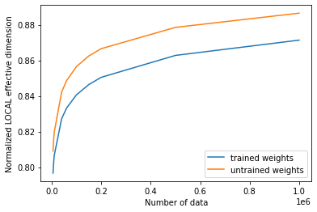

```python
# plot the normalized effective dimension for the model
plt.plot(n, np.array(local_eff_dim_trained) / opflow_qnn.num_weights, label="trained weights")
plt.plot(n, np.array(local_eff_dim_untrained) / opflow_qnn.num_weights, label="untrained weights")

plt.xlabel("Number of data")
plt.ylabel("Normalized LOCAL effective dimension")
plt.legend()
plt.show()
```

## 4. Future steps

- Implementation with runtime primitives
- Exploration of regularization techniques based on local effective dimension

## Thanks for listening!

## For further reference, see:

- Class source code: `qiskit-machine-learning/qiskit_machine_learning/neural_networks/effective_dimension.py`
- Tutorial: `qiskit-machine-learning/docs/tutorials/10_effective_dimension.ipynb`